# Forest Fragmentation Alters the Population Dynamics of a Late‐successional Tropical Tree - Zambrano - 2014 - Biotropica - Wiley Online Library

[Biotropica](https://onlinelibrary.wiley.com/journal/17447429)

[Volume 46, Issue 5](https://onlinelibrary.wiley.com/toc/17447429/2014/46/5) p. 556-564

Paper

Full Access

# Forest Fragmentation Alters the Population Dynamics of a Late-successional Tropical Tree

[Jenny Zambrano](https://onlinelibrary.wiley.com/action/doSearch?ContribAuthorRaw=Zambrano%2C+Jenny),

[Roberto Salguero-Gómez](https://onlinelibrary.wiley.com/action/doSearch?ContribAuthorRaw=Salguero-G%C3%B3mez%2C+Roberto),

First published: 18 August 2014

https://doi.org/10.1111/btp.12144

Citations: 14

## Abstract

Tropical late-successional tree species are at high risk of local extinction due to habitat loss and fragmentation. Population-growth rates in fragmented populations are predicted to decline as a result of reduced fecundity, survival and growth. We examined the demographic effects of habitat fragmentation by comparing the population dynamics of the late-successional tree *Poulsenia armata* (Moraceae) in southern Mexico between a continuous forest and several forest fragments using integral projection models (IPMs) during 2010–2012. Forest fragmentation did not lead to differences in population density and even resulted in a higher population-growth rate (*λ*) in fragments compared to continuous forests. Habitat fragmentation had drastic effects on the dynamics of *P. armata*, causing the population structure to shift toward smaller sizes. Fragmented populations experienced a significant decrease in juvenile survival and growth compared to unaltered populations. Adult survival and growth made the greatest relative contributions to *λ* in both habitat types during 2011–2012. However, the relative importance of juvenile survival and growth to *λ* was highest in the fragmented forest in 2010–2011. Our Life Table Response Experiment analysis revealed that positive contributions of adult fecundity explained most of the variation of *λ* between both habitats and annual periods. Finally, *P. armata* has a relatively slow speed of recovery after disturbances, compromising persistence of fragmented populations. Developing a mechanistic understanding of how forest fragmentation affects plant population dynamics, as done here, will prove essential for the preservation of natural areas.

As burgeoning human populations and industrialization lead to increased deforestation of natural habitats, fragmented landscapes are becoming a common feature of tropical forests worldwide (Laurance & Bierregaard 1997). The investigation of fragmented tropical landscapes has increased in recent years (Harrison & Bruna 1999), with many studies documenting decreased biodiversity and species persistence due to habitat fragmentation (Benitez-Malvido 1998, Laurance *et al*. 1998, 2000, Benitez-Malvido & Martinez-Ramos 2003, Arroyo-Rodriguez *et al*. 2007). Reductions in reproductive success (Aguilar *et al*. 2006), growth, and survival (Bruna 2002) have been hypothesized as the main drivers of population decline in forest fragments. Differences in the dynamics of fragmented and unfragmented plant populations result from decreased fruit production, due to reduced pollination (Aizen & Feinsinger 1994) and increased adult tree mortality (Laurance *et al*. 1997). Modification of recruitment-related factors such as reduced seed dispersal (Cordeiro *et al*. 2009), increased seed predation (Galetti *et al*. 2006), increased herbivory (Arnold & Asquith 2002), inbreeding depression (Young *et al*. 1996), and possibly altered microclimatic conditions (Bruna 1999) may result in further differences between the dynamics of fragmented and unfragmented plant populations. A few studies have focused only on the seed and seedling stages of fragmented plant populations (Benitez-Malvido 1998, Cordeiro & Howe 2001, Ashworth & Marti 2011) and are conducted over short periods, allowing experimental manipulations in a more straightforward way than following adult individuals. Consequently, we still lack a basic understanding of the demographic mechanisms behind the declines of fragmented plant populations. Such an understanding can only be attained by examining the whole life cycle of the species (Bruna *et al*. 2009).

Most of our knowledge on the effects of forest fragmentation on tropical plant population dynamics derives from matrix demographic approaches (see Bruna *et al*. 2009). Matrix population models (Caswell 2001) are a popular tool for describing population dynamics for several reasons, including their relative simplicity and flexibility to analyze plant population attributes such as population-growth rates (*λ*), transient dynamics (Salguero-Gómez & de Kroon 2010), or contributions to the life cycle of the species from the viewpoint of conservation efforts (Hodgson *et al*. 2006). The latter is of utmost interest here, as it allows for the evaluation of the relative importance of particular life-cycle stages (*e.g.,* juveniles *vs*. adults) or a vital rate (*e.g.,* survival, growth, reproduction) through the use of elasticity analyses (Menges 2000). However, projection matrix models have some limitations when dealing with life cycles that are best described as a continuous variable such as size (de Kroon *et al*. 2000, Zuidema & Franco 2001). Integral projection models have recently emerged as a valuable alternative in these cases, as they allow for the modeling of population dynamics based on both continuous and discrete state variables (reviewed in Easterling *et al*. 2000, Ellner & Rees 2006).

We explored how forest fragmentation in Southern Mexico affects the population dynamics of a long-lived, tropical tree species, *Poulsenia armata* (Moraceae) using IPMs and perturbation analyses. *Poulsenia armata* is a widespread tree occurring in Neotropical forests from Mexico to Bolivia. Therefore, this tree potentially offers intraspecific comparisons over millions of km<sup>2</sup>, allowing insights into variation in vital rates of species with similar life history traits that may greatly differ from site to site and region to region. Specifically, we tested for differences in population-growth rate and population structure in fragmented versus continuous forest populations.

Reduced recruitment and fecundity have been underlined as major threats to plant persistence in fragmented forests (Aguilar *et al*. 2006), though survival and growth of larger individuals may contribute the most to population-growth rate of long-lived trees (Pinero *et al*. 1984, Bruna *et al*. 2009). If forest fragmentation resulted in decreased adult survival and growth of *P. armata,* we would predict: (1) reduced *P. armata* densities in the fragmented forest compared to continuous forest; (2) lower population-growth rates for fragmented populations of *P. armata*; and (3) most of the variation in *λ* values between habitats is explained by differences in adult survival and growth. Alternatively, unfavorable changes to plant fecundity in fragments may severely limit plant recruitment leading to reduced population-growth rate (Bruna 2003). We further complete the picture of demographic differences between continuous and fragmented forests by calculating the rate at which both populations may recover following forest fragmentation using transient dynamic analysis.

## Methods

### Study site and species

We conducted the study in the continuous forest and nearby forest fragments at Los Tuxtlas forest in the state of Veracruz, southeastern Mexico (18°30′N, 95°04′W, 500 m asl) (Fig. S1). The original vegetation of the study site is lowland tropical rain forest (Guevara *et al*. 2004). Los Tuxtlas represents the northern most edge of the distribution of the tropical rain forest in the New World (Dirzo & García 1992); currently, 16 percent of the original forest in the region persists in the form of an archipelago of small forest fragments (Estrada *et al*. 1997, Fig. S1). Average temperature is 25°C in most of the study area, with slightly lower values (20–22°C) at higher altitudes (Guevara *et al*. 2004). Mean annual precipitation is 4900 mm, with a relatively dry period in March–May (111.7 ± 11.7 [SD] mm/mo) and a rainy season in June–February (486 ± 87.0 mm/mo) (Estrada & Coates-Estrada 2002). The continuous forest of this study comprises the 700-ha of the Los Tuxtlas Biological Station, which is embedded in 7500 ha of protected forest that forms the Los Tuxtlas Biosphere Reserve (Estrada & Coates-Estrada 2002).

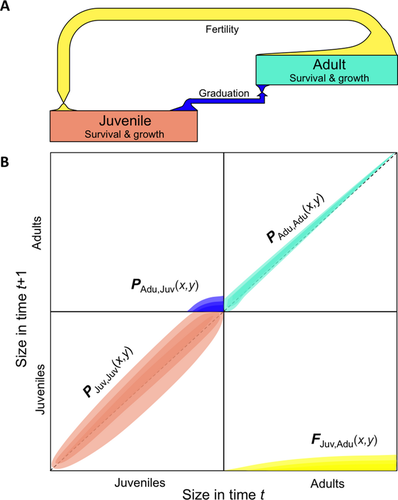

**Figure 1**

Diagram depicting (A) the life cycle of *Poulsenia armata* represented by two developmental stages, juvenile and adult, based on size and (B) the two-stage integral projection model used here to study the demographic effects of habitat fragmentation. The life cycle is represented by survival and growth of juveniles (**P**<sub>J</sub><sub>uv,Juv</sub>(*x*,*y*); ochre) and adults (**P**<sub>A</sub><sub>du,Adu</sub>(*x*,*y*); green), as well as the graduation of juveniles to adults (**P**<sub>A</sub><sub>du,Juv</sub>(*x*,*y*); blue) and the fertility of adults to small juveniles (**F**<sub>J</sub><sub>uv,Adu</sub>(*x*,*y*); yellow). The dashed diagonal line denotes individuals that survived and remained in the same life stage and size between year (stasis). (*Color version is available online as part of Supporting Information*).

*Poulsenia armata* (Miq.) Standl. is a shade-tolerant, late successional canopy tree of up to 30 m height (Croat 1978). Individuals are monoecious and produce separate male and female inflorescences. Flowers are pollinated by thrips (Thysanoptera (Sakai 2001). Fruits are produced in May–June and October–November; seeds are 7–9 mm long by 5–8 mm wide and weigh 0.146 ± 0.017 [SD] g. Here, we classified the life cycle of this species in two main stages: juveniles (0–150 cm height) and adults (>150 cm; Fig. 1A).

### Data collection

In 2010, we established eight 1-ha permanent vegetation plots in Los Tuxtlas forest. Four of these plots were haphazardly selected within the continuous forest based on the presence of reproductive individuals of *P. armata*, and were established >500 m away from the edge of the forest. We established the other four 1-ha plots at the center of four forest fragments located in the surrounding landscape (Fig. S1). This study included the forest fragments of Rancho Eugenia (19-ha), Playa Escondida (40-ha), Balzapote (35-ha) and Ruiz Cortines (~20-ha; Fig. S1); these fragments have been isolated from the continuous forest for 30–40 yr (Mendoza *et al*. 2005).

To estimate fecundity of adults of *P. armata*, we combined information from the permanent vegetation plots with data from a greenhouse experiment. During the reproductive season (May–June) of 2010, we collected a random sample of fruits from the continuous and fragmented forests for all reproductive adults. This allowed us to estimate the mean number of seeds per fruit as a function of adult size and habitat type. Pulp was carefully removed from seeds by rubbing them against a fine meshed screen under running water. We washed all seeds for 5 min in a dilute solution of sodium hypochlorite to avoid fungal infection. Seeds did not have any signs of predation and were viable based on a flotation test. We then recorded their probability of germination over 30 d; seeds of *P. armata* show no persistent dormancy and have been previously reported to germinate in <30 d (Rodriguez *et al*. 2000). We randomly selected two or three adult individuals from each plot for a total of nine reproductive trees in the continuous forests and another nine in the fragmented forest. We collected a total of 144 seeds (16 seeds per tree) from the continuous forest with 72 seeds planted in individual plastic bags with soil from the continuous forest and 72 seeds planted in soil from the fragmented forest. We applied the same treatment for seeds from the fragmented forest. Seeds were planted under the same conditions at the greenhouse of the Los Tuxtlas Biological Station. Our objective was to determine effects of maternal habitat and soil conditions on the germination probability of *P. armata* in a common garden experiment. We then included these results in our IPM to estimate the per-capita fecundity of adults (below) in the field. In the permanent vegetation plots, we also recorded the reproductive status for each individual as a binomial variable in 2010 and 2011. Finally, we estimated the *per capita* fruit production by directly counting fruits on five randomly selected branches per reproductive individual in 2010 and 2011; we multiplied the mean number of fruits per branch by the number of branches to estimate fruit production for each individual.

### Demographic model construction

To determine the effects of forest fragmentation on *P. armata*'s population dynamics, we constructed integral projection models (IPMs) using modified code from the *R* library *IPMpack* (Metcalf *et al*. 2013). IPMs describe population dynamics by linking the size *x* distribution of individuals at time *t, n*(*x,t*)*,* to their size *y* distribution *n*(*y,t +* 1) the next studied period, *t* + 1 (Easterling *et al*. 2000).

### Differences in vital rates within habitats and annual periods

We tested the impact of forest fragmentation on the underlying vital rates in our models with two-way ANOVA and examining if the vital rates of juvenile survival and growth (*P*<sub>Juv,Juv</sub>(*x*,*y*)), juvenile graduation (*P*<sub>Adu,Juv</sub>(*x*,*y*)), adult survival and growth (*P*<sub>Adu,Adu</sub>(*x*,*y*)), and adult reproduction (*F*<sub>Juv,Adu</sub>(*x*,*y*)), all varied as a function of habitat type (continuous *vs*. fragmented) and annual period (2010–2011, 2011–2012) or both. We conducted separate analyses for juveniles' and adults' demographic processes. Reproduction was described by the probability of reproduction of adults (*φ*<sub>*1*</sub>(*x*)), and the number of fruits produced per reproductive individual (*φ*<sub>*2*</sub>(*x*)). Additionally, we applied paired *t*-tests to determine if plant survival and growth significantly differed between juveniles and adults.

### Model output: population viability and contributions to the effects of fragmentation

Having found a significant variation in vital rates between habitat types and annual periods (Table 2), we constructed four separate IPMs based on habitat type and annual period to examine differences in population viability and their underlying demographic consequences of habitat fragmentation. Plot had no significant effect on growth (*F* = 0.18, *P* = 0.67), survival (*F* = 0.06, *P* = 0.99), fruit production (*F* = 0.23, *P* = 0.98) and probability of fruiting (*F* = 1.24, *P* = 0.26), therefore we built our IPMs pooling data based on habitat type and annual period. We first calculated the deterministic population-growth rate (*λ*). To compare effects of habitat and annual period on *λ*, we re-built IPMs and calculated the resulting *λ* using ordinary non-parametric bootstraps with 999 iterations without replacement, and then tested for significant differences in *λ* for habitats and annual periods using Kruskal–Wallis tests. To examine the main drivers of *λ* values, we calculated their elasticities to juvenile survival and growth (**P**<sub>Juv,Juv</sub>(*x*,*y*)), juvenile graduation (**P**<sub>Adu,Juv</sub>(*x*,*y*)), adult survival and growth (**P**<sub>Adu,Adu</sub>(*x*,*y*)), and adult reproduction (**F**<sub>Juv,Adu</sub>(*x*,*y*)). As we did with *λ*, we also ran 999 bootstraps followed by Kruskal–Wallis tests on the resulting elasticities to quantify significant differences among habitats and annual periods. We then calculated damping ratios from each IPM to estimate the time taken by populations of *P. armata* to reach a stable state following a disturbance (Caswell 2001).

Having found striking differences in population-growth rates between fragmented and continuous forests and annual periods, we conducted a Life Table Reponses Experiment (LTRE) (Caswell 2001, 2010) to explore the basis for such differences. An LTRE quantifies the effects of various vital rates such as survival, growth and reproduction on the population-growth rate of a given annual period and habitat type, and it helps us discern the main underlying drivers of differences between, in this case, population-growth rates from fragmented and continuous habitats (for more details see Supporting Information Appendix S2).

## Results

### Population density and structure

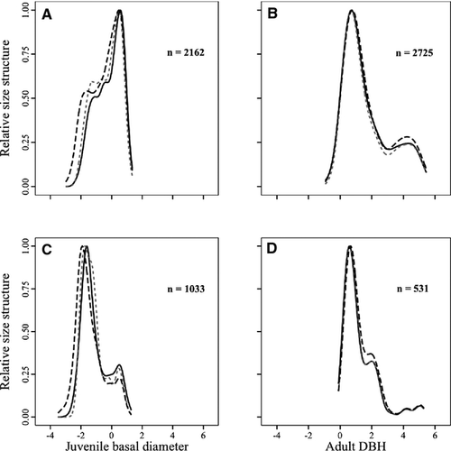

**Figure 2**

Observed size structure (log scale) of juveniles of *Poulsenia armata* in (A) continuous forest and (C) fragmented forest, and of adults in (B) continuous forest and (D) fragmented forest in the years 2010 (black solid line), 2011 (grey dotted line), and 2012 (black dashed line). Total number of observed individuals during the study is depicted on the top-right corner of each panel.

Table 1. Mean (± SE) population-growth rates (*λ*) for the annual periods 2010–2011 and 2011–2012 in populations of *Poulsenia armata* of continuous and fragmented forests at Los Tuxtlas. Values of *λ* ≥ 1, as obtained here, indicate demographic viability. Keyfitz' Δ reports how close to the observed size/stage structure of juveniles and adults in the population are to the stable stage distribution **w** (1: far from stationary equilibrium, 0: exactly as projected at stationary equilibrium conditions). Damping ratio specifies the rate at which the population returns to its stable size distribution after a disturbance

| Habitat | Annual period | *λ* | Keyfitz' *Δ* | Damping ratio |
| --- | --- | --- | --- | --- |
| Continuous forest | 2010–2011 | 1.04 ± 2.58 × 10<sup>−5</sup> | 0.59 | 1.06 ± 0.03 |
|  | 2011–2012 | 1.00 ± 2.06 × 10<sup>−8</sup> | 0.63 | 1.10 ± 0.06 |
| Fragmented forest | 2010–2011 | 1.19 ± 1.43 × 10<sup>−5</sup> | 0.63 | 1.09 ± 0.05 |
|  | 2011–2012 | 1.01 ± 4.11 × 10<sup>−.6</sup> | 0.64 | 1.02 ± 0.04 |

### Population growth rates

The population-growth rates of all habitat types × annual period combinations were *λ* ≥ 1, indicating demographic viability (Table 1). Population-growth rate was significantly higher (*χ*<sup>2</sup> = 1802.81, *P* < 0.001) in the fragmented forest in 2010–2011 when compared to the continuous forest in the same annual period (Table 1). In 2011–2012, the population-growth rate significantly decreased in the fragmented (*χ*<sup>2</sup> = 1790.31, *P* < 0.001) and continuous forests (*χ*<sup>2</sup> = 1781.69, *P* < 0.001) compared to 2010–2011 (Table 1).

### Variation in demographic functions within habitats and periods

Table 2. Results of the ANOVA tests showing differences between habitats and annual periods, and the interaction between both for juvenile and adult survival and growth (*σ* and *γ*, respectively), juvenile graduation to adults and adult fecundity depicted by fruiting probability (*φ*<sub>1</sub>) and number of fruits per reproductive adult of *Poulsenia armata* (*φ*<sub>2</sub>)

| Life stages | Vital rates | Habitat | Annual period | Habitat × annual period |
| --- | --- | --- | --- | --- |
| Juvenile | *σ* | *F* = 138.57** | *F* = 26.82** | *F* = 12.65** |
|  | *γ* | *F* = 100.67** | *F* = 3.38* | *F* = 2.72<sup>NS</sup> |
| Adult | *σ* | *F* = 11.43** | *F* = 21.19** | *F* = 0.37<sup>NS</sup> |
|  | *γ* | *F* = 4.73* | *F* = 0.96<sup>NS</sup> | *F* = 1.21<sup>NS</sup> |
|  | *φ* <sub>*1*</sub> | *F* = 24.15** | *F* = 0.26<sup>NS</sup> | *F* = 0.29<sup>NS</sup> |
|  | *φ* <sub>*2*</sub> | *F* = 5.05* | *F* = 5.76* | *F* = 0.01<sup>NS</sup> |

- <sup>NS</sup>No statistical significance; *Significant at *P* < 0.05; **Significant at < 0.001.

Adult fecundity was strongly size dependent, with the probability of fruiting (*φ*<sub>*1*</sub>(*x*)) and number of fruits produced per reproductive individual (*φ*<sub>*2*</sub>(*x*)) increasing with adult size (Figs. S6, S7). The relationship between fruiting probability and adult size was highly variable between habitats, but not among annual periods (Table 2). Probability of fruiting was significantly lower in the continuous forest (mean = 0.04 ± 0.01 SE) than in the fragmented forest (0.13 ± 0.03) (Table 2). Similarly, the number of fruits per reproductive adult varied among habitats and annual periods (Table 2). The number of fruits produced was greater from 2010–2011 (mean = 112.22 ± 17.50 fruits per adult) than from 2011–2012 (mean = 70.83 ± 9.18 fruits per adult) and in the continuous forest (134.70 ± 16.0 fruits per adult) when compared to fragmented forest (mean = 61.67 ± 11.91 fruits per adult).

### Elasticity and LTRE analyses

Elasticity values, which represent the effects of proportional changes in demographic processes of the IPM onto its population-growth rate *λ*, varied significantly across habitats (Fig. 3). Adult survival and growth, integrated into the sub-kernel *P*<sub>Adu,Adu</sub>(*x,y*) (Fig. 1B), were of greater importance to *λ* in both habitats during 2011–2012, especially in the continuous forest (*χ*<sup>2</sup> = 1640.95, *P* < 0.001; Fig. 3B). However, juvenile survival and growth, in the sub-kernel *P*<sub>Juv,Juv</sub>(*x,y*), made the largest contribution to population-growth rate in the fragmented forest during the first annual period (*χ*<sup>2</sup> = 1645.92, *P* < 0.001), while adult survival and growth had a stronger impact on *λ* in the continuous forest (*χ*<sup>2</sup> = 1548.71, *P* < 0.001; Fig. 3A). We found that graduation from juveniles to adults, *P*<sub>Adu,Juv</sub>(*x,y*), and adult reproduction, *F*<sub>Juv,Adu</sub>(*x,y*), had the lowest elasticities in both habitats (Figs. 3A and B). Finally, graduation from juveniles to adults had a larger relative effect on *λ* in the fragmented forest in both annual periods than in the continuous forest (Fig. 3A; 2010–2011: *χ*<sup>2</sup> = 1641.11, *P* < 0.001; 2011–2012: *χ*<sup>2</sup> = 1788.46, *P* < 0.001). Similarly, adult fecundity had a stronger impact on *λ* in the fragmented forest compared to the continuous forest (2010–2011: *χ*<sup>2</sup> = 1637.9, *P* < 0.001; 2011–2012: *χ*<sup>2</sup> = 1781.13, *P* < 0.001).

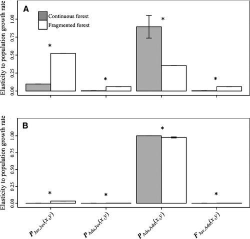

**Figure 3**

Mean (± SE) elasticity values of various demographic processes to the population-growth rates (*λ*) of *Poulsenia armata* integral projection models fitted to data from populations in the continuous and fragmented forests during the annual period of (A) 2010–2011 and (B) 2011–2012. Elasticities were calculated for juvenile survival and growth (**P**<sub>J</sub><sub>uv,Juv</sub>(*x*,*y*)), juvenile graduation (**P**<sub>A</sub><sub>du,Juv</sub>(*x*,*y*)), adult survival and growth (**P**<sub>A</sub><sub>du,Adu</sub>(*x*,*y*)), and adult reproduction (**F**<sub>J</sub><sub>uv,Adu</sub>(*x*,*y*)). Asterisks indicate statistically significant (*P* < 0.001) differences in each demographic process within each habitat type.

Our LTRE analysis revealed that juveniles and adults did not contribute equally to the observed differences in population-growth rates between habitats and annual periods (Fig. 4; Table 1). The largest contribution to such differences in *λ* corresponded to adults, where positive contributions of adult fecundity during 2010–2011 in the fragmented forest explained most of the variation of *λ* between both habitats (Fig. 4A). Graduation from juveniles to adults had an intermediate positive contribution to *Δλ* in the annual period of 2010–2011. Differences in juvenile and adult survival and growth made lower contributions to *λ*, especially during 2011–2012 (Fig. 4B).

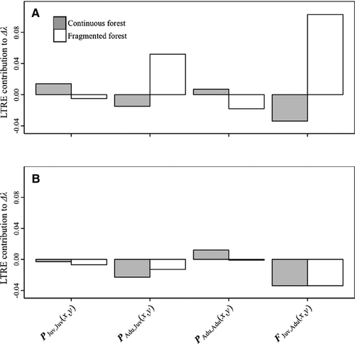

**Figure 4**

Life Table Response Experiment (LTRE) analysis of contribution of each demographic process to the differences in population-growth rate *λ* between the continuous and fragmented forests during the annual period of (A) 2010–2011 and (B) 2011–2012 using. The demographic processes are juvenile survival and growth (**P**<sub>J</sub><sub>uv,Juv</sub>(*x*,*y*)), juvenile graduation (**P**<sub>A</sub><sub>du,Juv</sub>(*x*,*y*)), adult survival and growth (**P**<sub>A</sub><sub>du,Adu</sub>(*x*,*y*)), and adult reproduction (**F**<sub>J</sub><sub>uv,Adu</sub>(*x*,*y*)).

## Discussion

The lack of regeneration of tropical late-successional species is of critical concern for the long-term persistence of biodiversity in fragmented landscapes (Cole *et al*. 2011). Research to date has provided limited answers on how habitat fragmentation affects population dynamics of late-successional trees. Though forest fragmentation did not consistently reduce population density of *Poulsenia armata* in Las Tuxtlas, and it even resulted in higher population-growth rates compared to the continuous forest, the dynamics of fragmented populations of *P. armata* differed considerably when compared to populations in our control site.

### Impact of forest fragmentation on the dynamics of *Poulsenia armata*

Our study revealed that survival and growth of adults, and to a lesser extent of juveniles, were the most important demographic processes influencing the viability of *P. armata* in both habitat types. This finding is in agreement with our understanding of life history theory in long-lived organisms (Silvertown *et al*. 1993). However, we found that annual period, and not just habitat type, had an important effect on the demography of *P. armata*. Such an annual variability in demographic patterns was showcased by our LTRE and elasticity analysis, which together identified 2010–2011 as a ‘good’ period for juvenile and adult survival and growth, resulting in greater population-growth rates than in 2011–2012. Differences in lambda between habitat types and annual periods were mainly explained by the positive contribution of adult fecundity in the fragmented forest during 2010–2011. In 2011–2012, decreased population-growth rate was indeed the result of reduced survival and growth of juveniles in the fragmented forest, while in continuous forest decreased adult survivorship and growth led to decreased population-growth rates. Though our study is based on only two transition years, the fact that patterns of survival and growth varied similarly in the continuous and fragmented forests might suggest that larger-scale regional drivers, such as climate, are influencing demography (Gagnon *et al*. 2011).

### Mechanisms behind changes in population dynamics

Significant decreases in juvenile survival and growth during 2011–2012 coincided with a record drought induced by La Niña (Lobato-Sanchez *et al*. 2012). In addition, the positive contribution of fecundity to differences in *λ* between habitats also suggests that *P. armata* have different patterns of reproduction in fragments, which could also influence persistence. We note that caution should be taken when interpreting our results of adult fecundity, because seed germination (included in the **F** sub-kernel) could be affected if they are ingested by mammals (Traveset 1998)—something we did not account for in our study. The primary seed dispersers of *P. armata* in this area are howler monkeys (*Alouatta palliata*) (Estrada & Coates-Estrada 1984), and the germination of seeds recovered from feces was higher (Estrada & Coates-Estrada 1986), However, seed germination also depends also on abiotic conditions, and changes in these conditions appear to influence differences observed in the fecundity of *P. armata*, resulting in a trade-off favoring seed quantity over quality and ultimately reducing offspring performance (J. Zambrano & M. Gonzalez-Meler, unpubl. data). We speculate the result of these changes is the reduced survival and growth of seedlings in fragments. Finally, the changes we observed could result from differences in seed dispersal (Uriarte *et al*. 2011). This may be the case at Los Tuxtlas, where declines or local extinction of howler monkeys have been documented in fragments (Arroyo-Rodriguez & Mandujano 2006a). Although seed predation could also alter seedling demography, this may not be the case in our system. Small rodents appear to increase in abundance in disturbed forests (Arroyo-Rodriguez & Mandujano 2006a), but large-seeded species such *P. armata* are less preferred by small mammals and hence become overrepresented on the forest floor (Dirzo *et al*. 2007, Zambrano *et al*. 2014).

### Conservation implications

Demographic analyses of dominant species are key to understanding not only population viability but also the conservation status of studied habitats (Hansen *et al*. 1999). Although the population structure of *P. armata* has been drastically altered in fragments, our findings are consistent with previous work that primary arboreal elements of unaltered forests are still present in large remnant patches at Los Tuxtlas (Arroyo-Rodriguez & Mandujano 2006b). This suggests this fragmented forest may be resilient in ways that have yet to be fully explored.

## Acknowledgments

We thank the staff members of Los Tuxtlas Biological Station and members of the Laguna Escondida and Balzapote communities for their assistance in the field. Fieldwork was supported by grants from Rufford Foundation, Idea Wild, Sigma Xi and a Hadley Award from the University of Illinois at Chicago to J.Z. R.S-G. was supported by an ARC DECRA fellowship.